# survey-first-glance

Dorien Huijser

8 April 2022

This file contains some first-glance plots of the frequency of responses for each question in the survey. A full report will be generated in another Rmd file.

## Analysis plan

1. Overall (no split per faculty or position, entire UU): counts, percentages, graphs
2. Split by faculty, possibly department (for organization purposes): counts, percentages, graphs
3. Generate a first report of the report to share and present. Ask for input: what else do people want to know? Ideas for other ways to analyse?
4. After feedback, possible split by Position (for teaching purposes).
5. If relevant, split per faculty and position (if not too small of a sample)

### Useful links for prettifying

- https://www.data-to-viz.com/
- https://r-graph-gallery.com/
- https://holtzy.github.io/Pimp-my-rmd/
- Coolers: color palette with UU colors

## Data exploration

The survey was filled out by 163 researchers. The median time it took to complete the survey was 8.7 minutes (range: 0.6 minutes - 5.1 days). The majority of researchers (83.4%) fully completed the survey.

We received responses from each faculty, but the distribution is not equal: the faculties of Science and Social and Behavioural Sciences are overrepresented, whereas the responses of the Faculty of Geosciences and the Faculty of Medicine are rather low. This can be explained by the fact that a large chunk of research performed at the Faculty of Geosciences does not investigate human behavior and therefore does not work with personal data much. The Faculty of Medicine, then, is located at the University Medical Center Utrecht (UMCU) and is not of primary interest for the current survey, as it concerns an entirely different organization and research support structure.

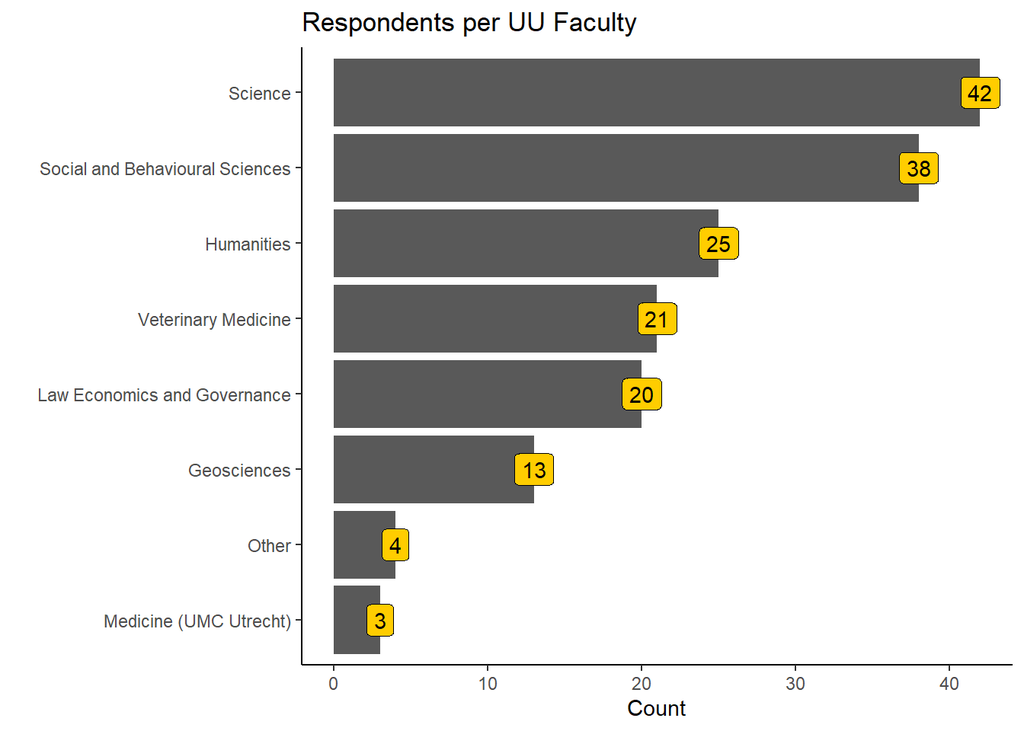

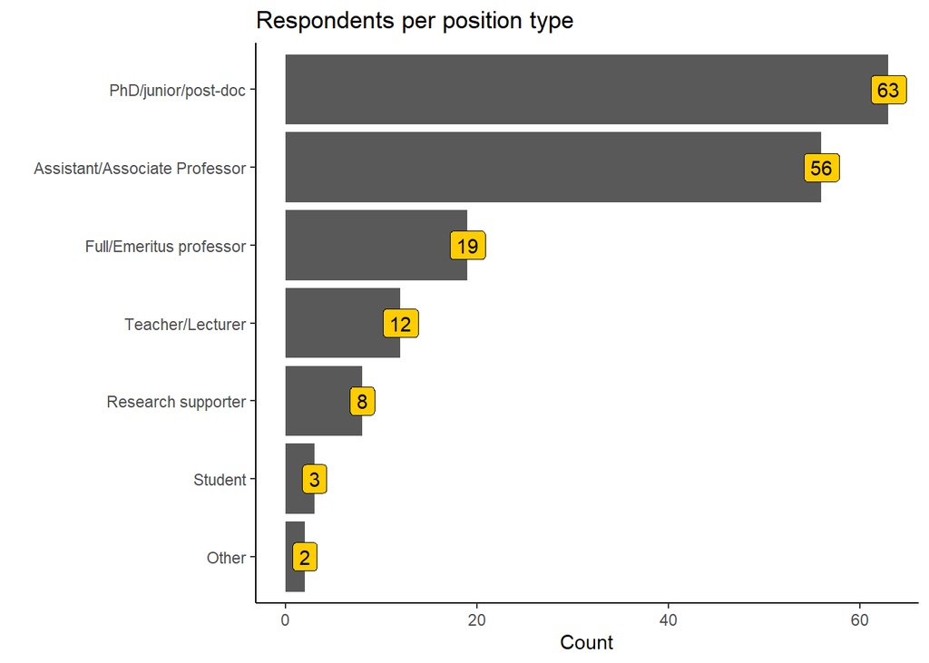

Below the division of position per faculty is plotted:

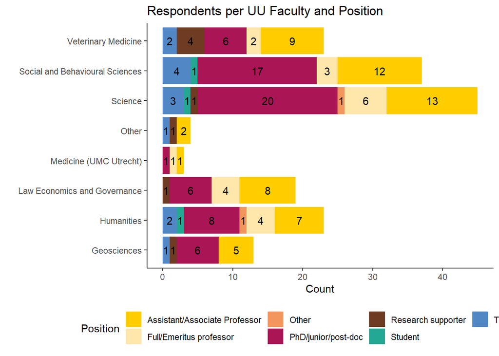

## Types of data

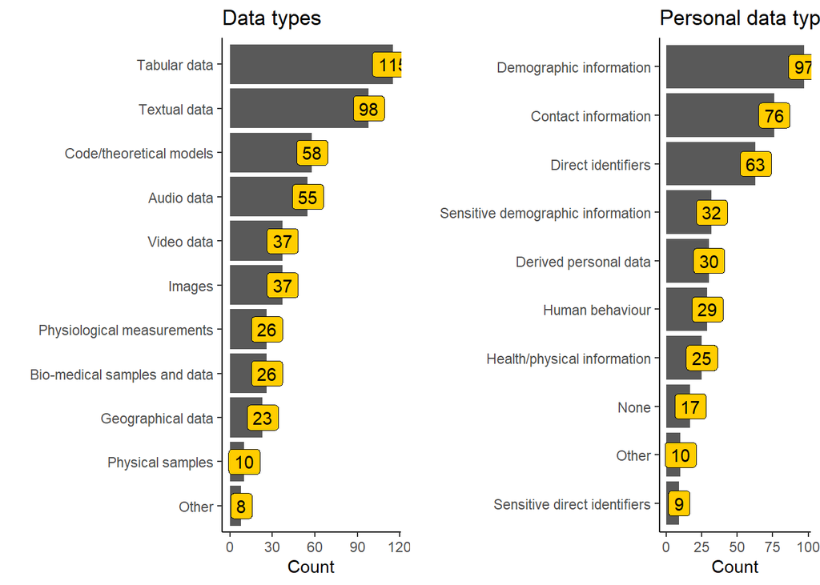

## Organisational and technical measures

### Organisational measures and storage media used

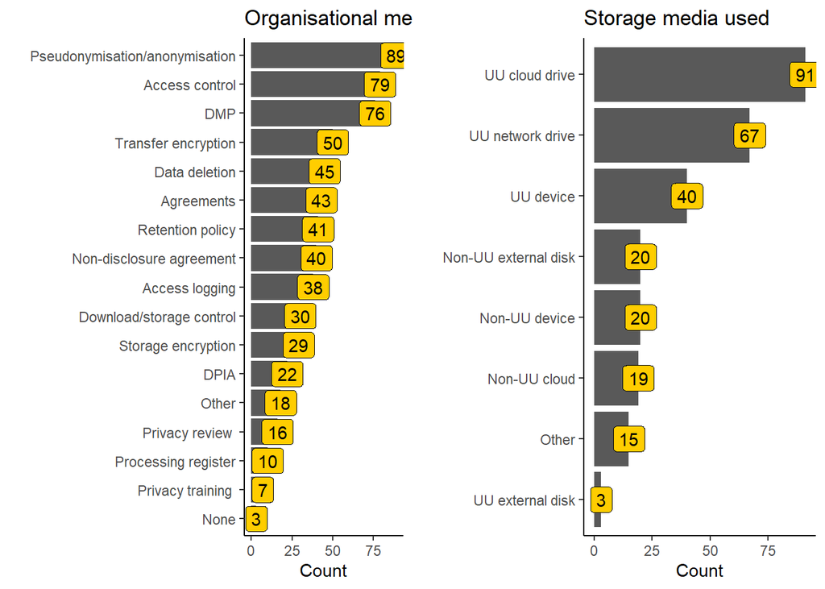

### Informed consent forms

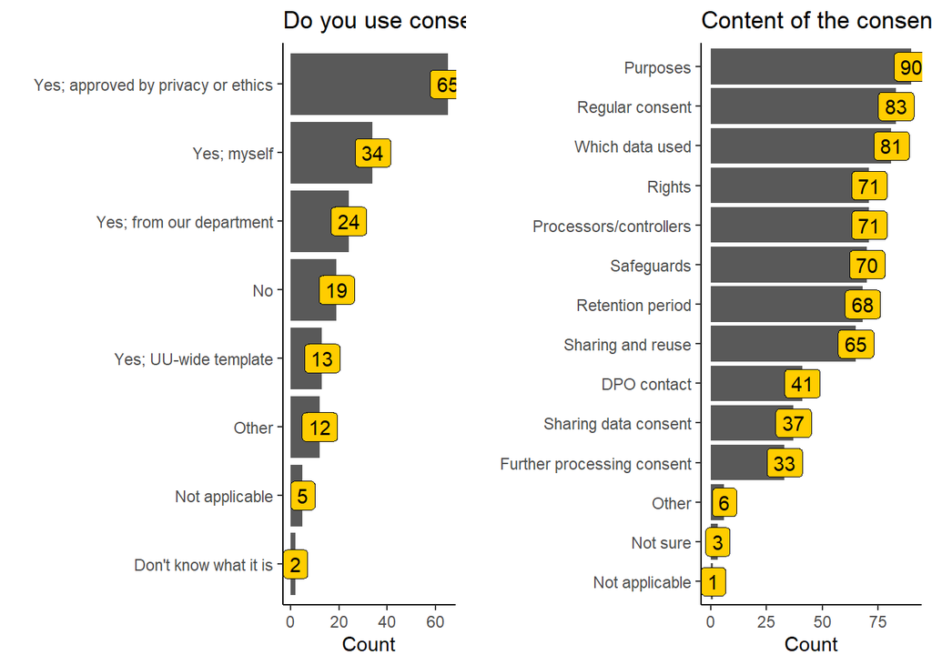

### Data Protection Impact Assessment (DPIA)

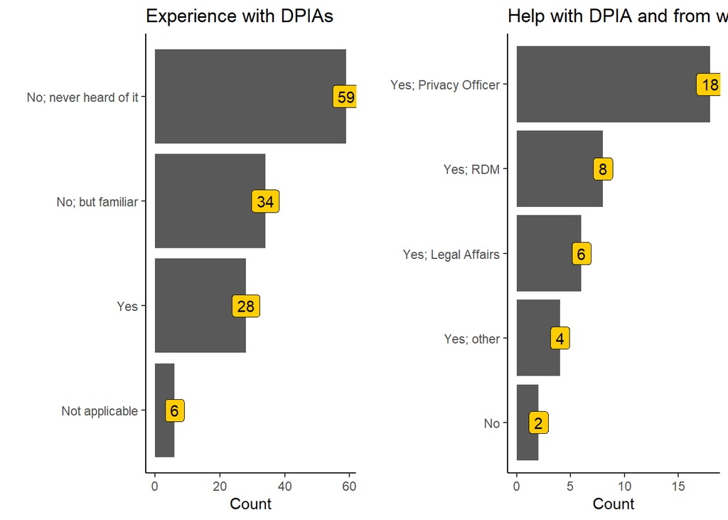

## Data sharing and publication

### External data sharing

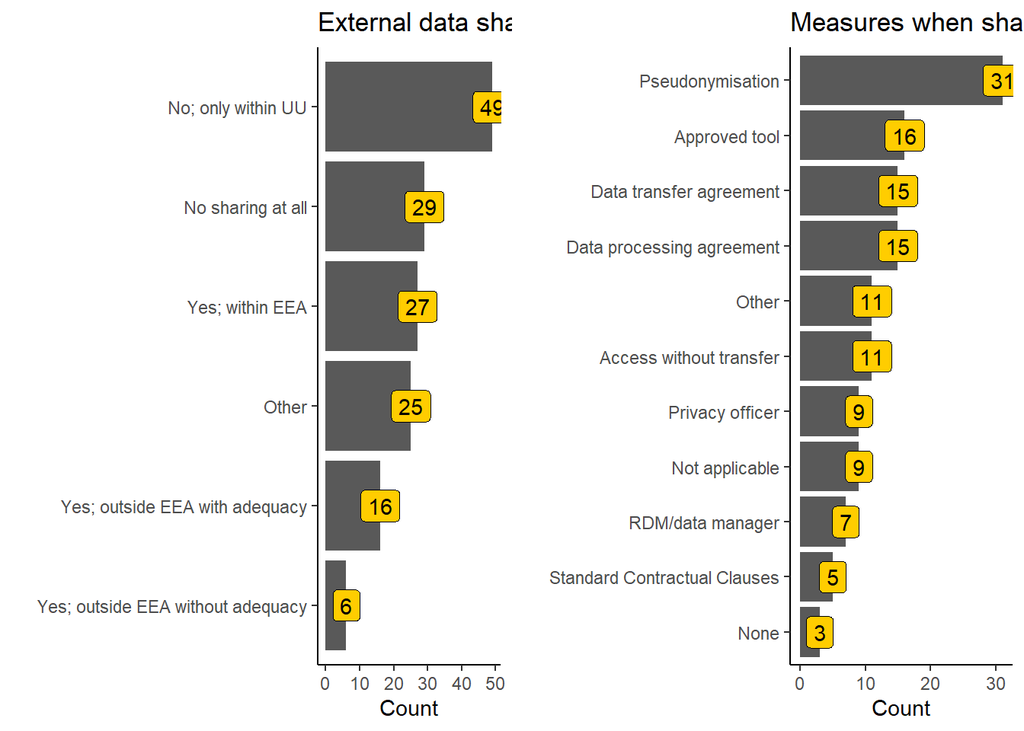

### Data publishing

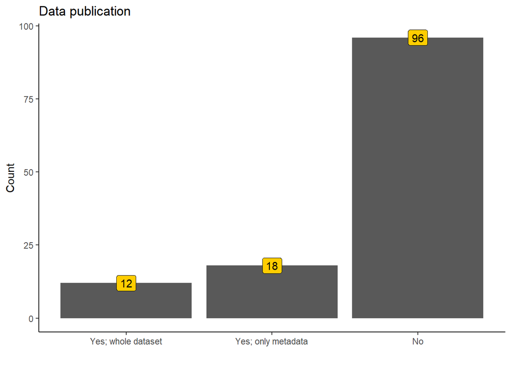

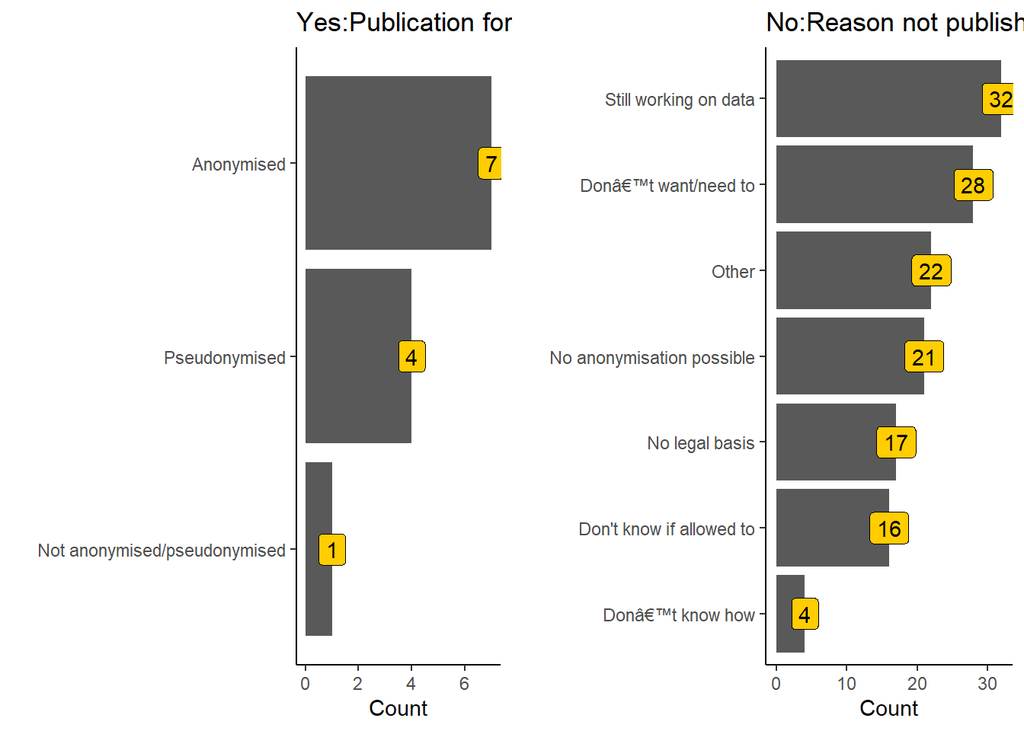

## Existing support

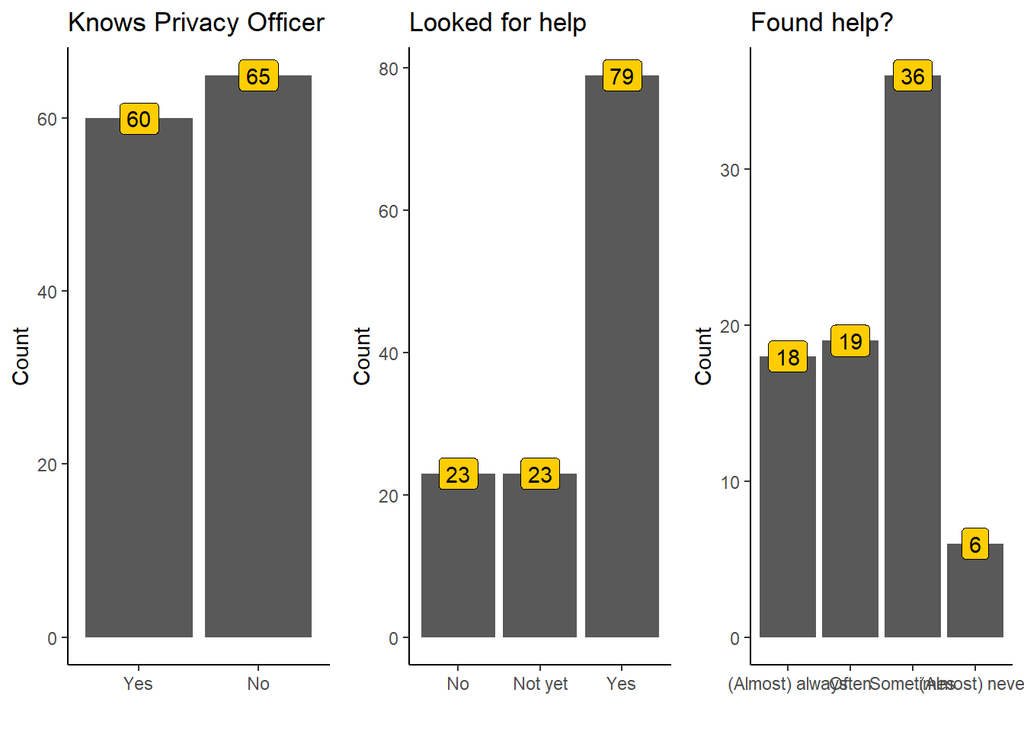

Sources used:

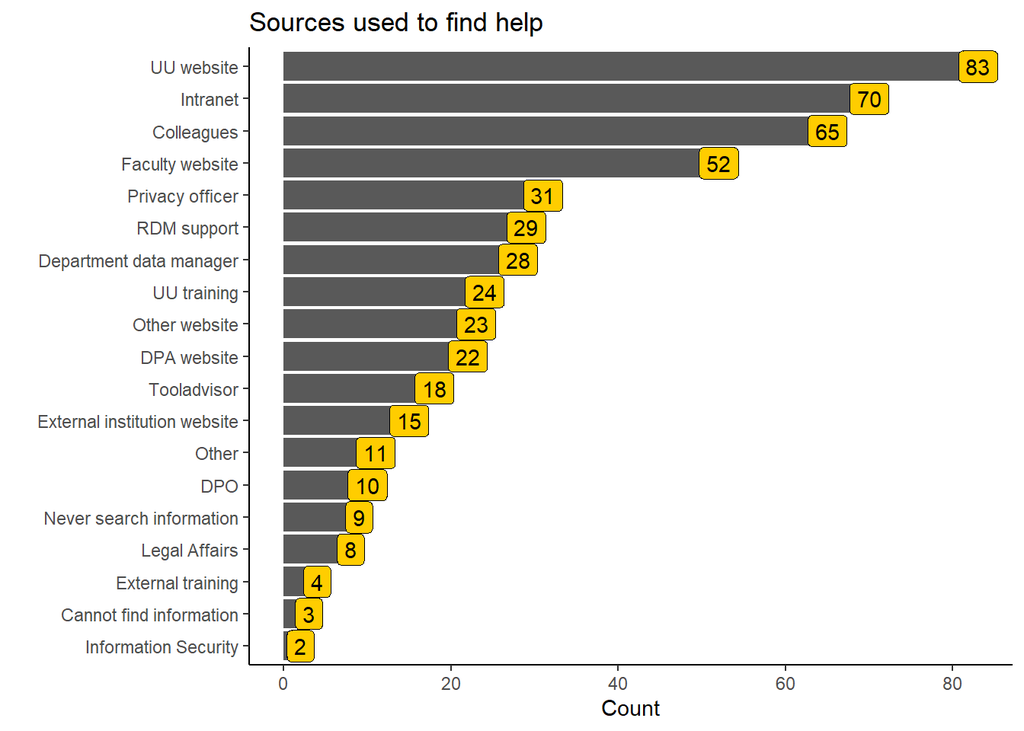

## Support required

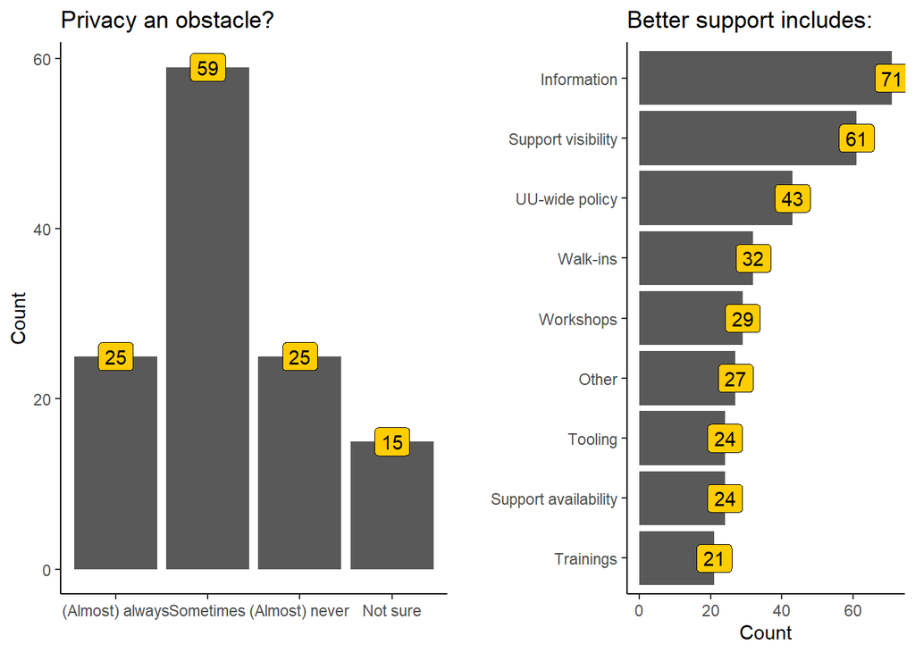

There are many questions with open text responses (questions with an “Other, namely” option and Infotools_missing and Better_support variables), which are harder to analyze but extremely important to take into account in the Data Privacy Project. These need to be scored manually (?).

### Interviews

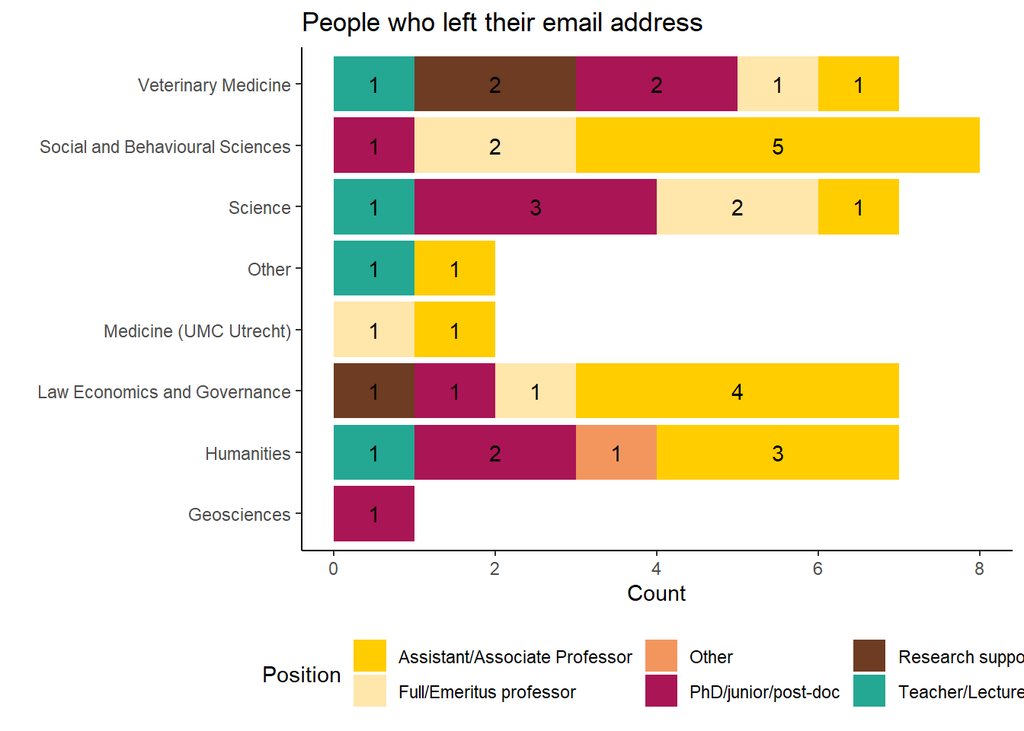

## Technical info

This document was last created on: 2022-04-25.